# Moving Average Process

Time Series

Description for Moving Average Process

Yeongeun Jeon , Jung In Seo  
2024-01-10

- **참고 : Statistics and Data Analysis for Financial Engineering**

# **1. 함수 설명**

- 관측된 시계열에 이동평균모형(Moving Average Model)을 구축하는 데 유용한 함수를 요약하면 다음과 같다.

| 함수 | 설명 |
| --- | --- |
| `arima()` | MA모형의 차수 $q$를 지정하여 모형 구축 |
| `auto.arima()` | 모형의 차수 지정없이 자동적으로 최적화된 모형 구축 |
| `acf()` | 상관도표그림 |
| `pacf()` | 부분상관도표그림 |
| `Box.test()` | Ljung-Box Test |
| `checkresiduals()` | 잔차가 백색잡음과정의 가정을 만족하는지 확인할 때 사용 |
| `forecast()` | 예측 |

# **2. 예제**

## **2-1. BMW 데이터셋**

- Package `"evir"`에서 제공하는 BMW 데이터셋은 1973년 1월부터 1996년 7월 사이에 BMW 주식의 일별 로그 수익률에 대한 시계열 데이터셋이다.

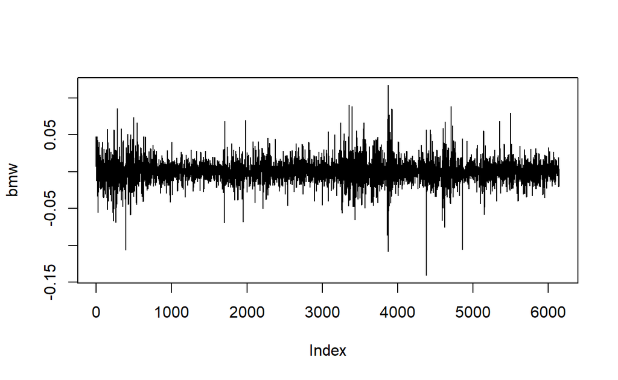

```r
# 패키지 설치
pacman::p_load("evir")

# 데이터 불러오기
data(bmw, package = "evir")

# 시계열 그림
plot(bmw, type = "l")
```

`Result!` 증가하거나 감소하는 추세가 없어서 시간의 흐름에 따라 평균이 일정하다.

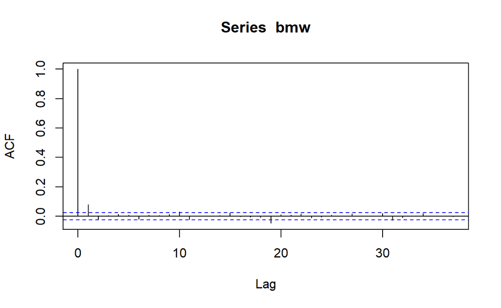

```r
# 상관도표그림
acf(bmw)
```

`Result!` 시차 1에서 막대의 끝이 파란색 선을 넘어가므로 시차 1에 대해 유의한 자기상관관계가 존재한다.

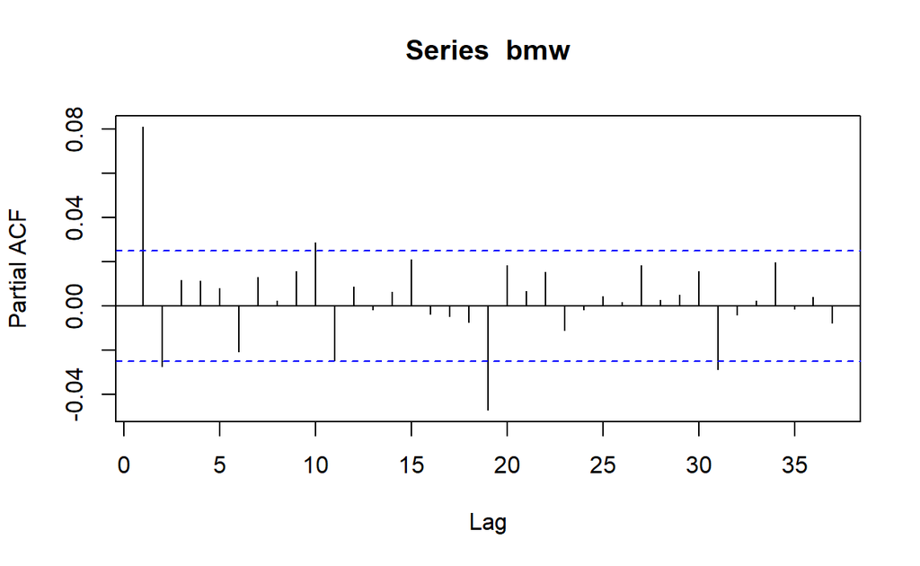

```r
# 부분상관도표그림
pacf(bmw)
```

`Result!` 시차 1에서 막대의 끝이 파란색 선을 넘어가므로 시차 1에 대해 유의한 부분자기상관관계가 존재한다.  
`Caution!` 큰 시차에서의 막대 끝이 파란색 선을 넘어가는 것은 우연 변동에 의한 가능성이 높다.

```r
# Ljung-Box Test
Box.test(bmw, lag = 5,
         type = "Ljung-Box")
```

```
    Box-Ljung test

data:  bmw
X-squared = 44.987, df = 5, p-value = 1.46e-08
```

`Result!` 귀무가설 $H_0 : \rho(1)=\rho(2)=\cdots=\rho(5)=0$에 대한 검정 결과에 따르면, $p$값이 0에 가까우므로 유의수준 0.05에서 귀무가설을 기각한다. 즉, 관측된 시계열에 대해 $\rho(1), \rho(2),\cdots,\rho(5)$ 중 유의한 자기상관관계가 적어도 1개 존재한다.

```r
# Fit MA(1)
MA.bmw <- arima(bmw,
                order = c(0, 0, 1))
```

`Caution!` 함수 `arima()`를 이용하여 MA(1) 모형을 구축하려면 옵션 `order = c(0, 0, 1)`을 입력한다. 만약, MA($q$) 모형을 구축하려면 옵션 `order = c(0, 0, q)`을 입력하면 된다.

```r
# 모형 추정 결과
print(MA.bmw)
```

```
Call:
arima(x = bmw, order = c(0, 0, 1))

Coefficients:
         ma1  intercept
      0.0853      3e-04
s.e.  0.0130      2e-04

sigma^2 estimated as 0.0002162:  log likelihood = 17213.39,  aic = -34420.79
```

`Result!` 출력 결과를 요약하면 다음과 같다.  
1. 모수의 추정치는 $\hat{\mu}=0.0003$, $\hat{\theta}=0.0853$, $\hat{\sigma}^2_\epsilon = 0.0002162$이다. 이를 이용하면 관측된 시계열에 대해 구축된 MA(1) 모형은 $Y_t-0.0003 = \epsilon_t + 0.0853\epsilon_{t-1}$이다.  
2. ${\theta}$에 대한 유의성 검정을 수행하면, 검정통계량은 $t = (0.0853/0.0130) \approx 6.56$이며 귀무가설($H_0 : \theta=0$)하에서 자유도가 $6145$ (관측값 $- 1$)인 $t$ 분포를 따르고 $p$값이 0에 가깝다. 이에 기반하여 유의수준 0.05에서 $p$값이 0.05보다 작기 때문에 귀무가설을 기각한다. 즉, $\hat{\theta}$의 값이 굉장히 작지만 ${\theta}$는 통계적으로 유의하다.

```r
# 잔차를 이용한 모형 진단
Box.test(residuals(MA.bmw), lag = 5,
         type = "Ljung-Box",
         fitdf = 1)                 # MA 모형의 추정한 회귀 모수 theta 개수
```

```
    Box-Ljung test

data:  residuals(MA.bmw)
X-squared = 4.7355, df = 4, p-value = 0.3155
```

`Caution!` 잔차는 함수 `residuals()`를 이용하여 추출할 수 있다.  
`Result!` 귀무가설 $H_0 : \rho(1)=\rho(2)=\cdots=\rho(5)=0$에 대한 검정 결과에 따르면, $p$값이 0.3155이므로 유의수준 0.05에서 $p$값이 0.05보다 크기 때문에 귀무가설을 기각하지 못한다. 즉, 잔차에 대해 시차 5까지의 자기상관계수 $\rho(1), \rho(2), \cdots, \rho(5)$ 중 유의한 자기상관계수가 적어도 1개 존재한다는 증거가 부족하며, 해당 시계열에 대해 MA(1) 모형을 가정하는 것이 적절하다.

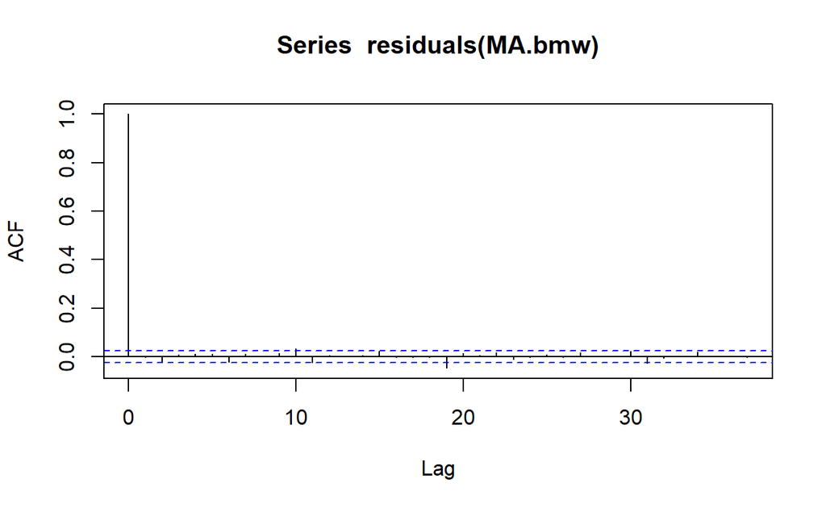

```r
# 잔차에 대한 상관도표그림
acf(residuals(MA.bmw))
```

`Result!` 시차 1 이상에서 막대의 끝이 파란색 선 밖에 나가지 않으므로 유의한 자기상관계수가 존재한다는 증거가 부족하다. 큰 시차(예를 들어, 시차 19)에서 막대의 끝이 파란색 선 밖에 나가는 것은 우연 변동에 의한 가능성이 높다.

`Caution!` 관측된 시계열의 개수가 많은 경우, 큰 시차에서 유의한 자기상관계수가 존재할 수 있다.

```r
# 잔차를 이용한 모형 진단
Box.test(residuals(MA.bmw), lag = 15,
         type = "Ljung-Box",
         fitdf = 1)                 # MA 모형의 추정한 회귀 모수 theta 개수
```

```
    Box-Ljung test

data:  residuals(MA.bmw)
X-squared = 22.045, df = 14, p-value = 0.0777
```

```r
# 잔차를 이용한 모형 진단
Box.test(residuals(MA.bmw), lag = 20,
         type = "Ljung-Box",
         fitdf = 1)                 # MA 모형의 추정한 회귀 모수 theta 개수
```

```
    Box-Ljung test

data:  residuals(MA.bmw)
X-squared = 37.311, df = 19, p-value = 0.007254
```

## **2-2. Mishkin 데이터셋**

- Package `"Ecdat"`에서 제공하는 Mishkin 데이터셋은 1950년 2월부터 1990년 12월 사이에 인플레이션율에 대한 시계열 데이터셋이다.

```r
# 패키지 설치
pacman::p_load("Ecdat")

# 데이터 불러오기
data(Mishkin, package = "Ecdat")
y = as.vector(Mishkin[,1])             # 월별 인플레이션율 추출
y
```

```
  [1] -3.552289  5.247540  1.692860  5.064298  6.719322 11.668920
  [7]  9.912501  8.346786  6.517766  4.865085 16.076321 19.154240
 [13] 14.061910  4.650814  1.546310  4.627010 -1.540355  1.540355
 [19]  0.000000  7.672257  6.102576  6.209472  4.533152  0.000000
 [25] -7.564866  0.000000 19.570490 -1.494151  1.494151  0.000000
 [31] -1.494151  0.000000  1.494151  0.000000 -1.494151 -2.993894
 [37] -6.010291  3.008908  1.501630  2.997634  4.482457  2.979029
 [43]  2.971549  1.483071  2.960655 -4.443726 -1.484906  2.967978
 [49] -1.483071 -1.484906 -2.839906  2.839906  1.484906  0.000000
 [55] -1.484906 -2.839906 -2.982291  2.982291 -2.982291  0.000000
 [61]  0.000000  1.492020  0.000000  0.000000  0.000000  2.978693
 [67] -2.978693  4.330177  0.000000  1.484906 -2.836390  0.000000
 [73]  0.000000  2.836390  1.483071  5.914023  5.751562  8.774637
 [79] -1.457907  1.457907  5.682521  1.449363  2.893485  0.000000
 [85]  2.886525  2.748830  2.873018  2.866156  7.006195  5.678584
```

[output cut: 67 more lines]

```r
# 시계열 ts 객체로 변환
y <- ts(y,
        frequency = 12,                # 1년에 12번 관측하는 월별 시계열열
        start = c(1950, 2))            # 1950년 2월부터 관측

y
```

```
           Jan       Feb       Mar       Apr       May       Jun
1950           -3.552289  5.247540  1.692860  5.064298  6.719322
1951 19.154240 14.061910  4.650814  1.546310  4.627010 -1.540355
1952  0.000000 -7.564866  0.000000 19.570490 -1.494151  1.494151
1953 -2.993894 -6.010291  3.008908  1.501630  2.997634  4.482457
1954  2.967978 -1.483071 -1.484906 -2.839906  2.839906  1.484906
1955  0.000000  0.000000  1.492020  0.000000  0.000000  0.000000
1956  0.000000  0.000000  2.836390  1.483071  5.914023  5.751562
1957  0.000000  2.886525  2.748830  2.873018  2.866156  7.006195
1958  7.020216  1.399128  6.844860  2.777502  0.000000  1.386248
1959  1.381556 -1.381556  0.000000  1.381556  1.254555  5.504627
1960  1.364560  0.000000  6.799529  0.000000  2.586158  0.000000
1961  1.343314 -1.343314  1.343314  0.000000  1.341812  5.230890
1962  2.664529  2.658626  2.532271  0.000000  0.000000  2.647071
1963  1.315600  1.194725  0.000000  0.000000  5.242814  3.917133
```

[output cut: 69 more lines]

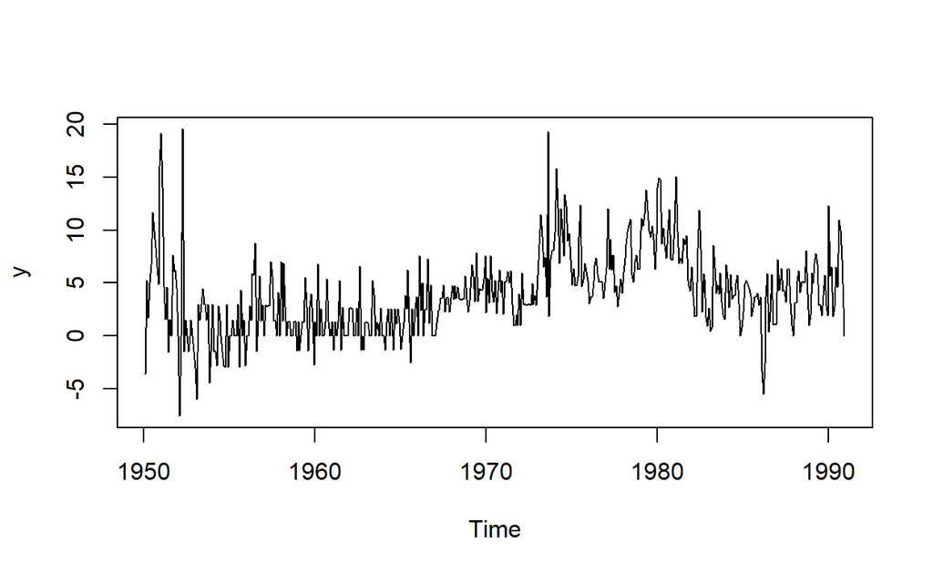

```r
# 시계열 그림
plot(y, type = "l")
```

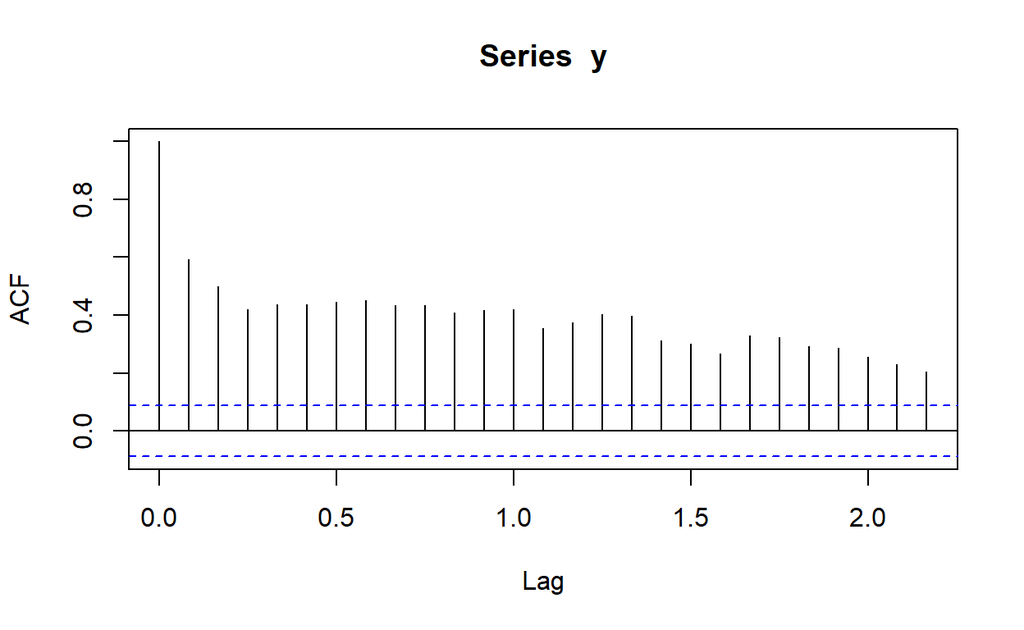

```r
# 상관도표그림
acf(y)
```

`Result!` 대부분의 시차에서 막대의 끝이 파란색 선을 넘어가므로 시차 25까지 유의한 자기상관관계가 존재한다.

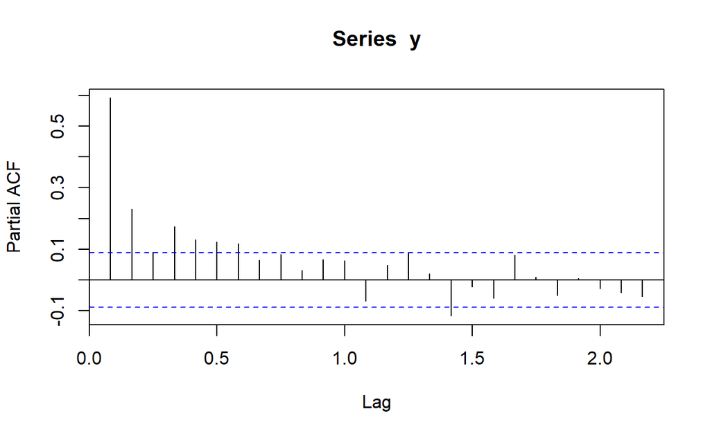

```r
# 부분상관도표그림
pacf(y)
```

`Result!` 시차 7까지 막대의 끝이 파란색 선을 넘어가므로 시차 7까지 유의한 부분자기상관관계가 존재한다.

```r
# Ljung-Box Test
Box.test(y, lag = 7,
         type = "Ljung-Box")
```

```
    Box-Ljung test

data:  y
X-squared = 774.34, df = 7, p-value < 2.2e-16
```

`Result!` 귀무가설 $H_0 : \rho(1)=\rho(2)=\cdots=\rho(7)=0$에 대한 검정 결과에 따르면, $p$값이 0에 가까우므로 유의수준 0.05에서 귀무가설을 기각한다. 즉, 관측된 시계열에 대해 $\rho(1), \rho(2),\cdots,\rho(7)$ 중 유의한 자기상관관계가 적어도 1개 존재한다.

```r
# Fit MA(1)
MA.y <- arima(y,
              order = c(0, 0, 1))

# 잔차를 이용한 모형 진단
Box.test(residuals(MA.y), lag = 5,
         type = "Ljung-Box",
         fitdf = 1)                 # MA 모형의 추정한 회귀 모수 theta 개수
```

```
    Box-Ljung test

data:  residuals(MA.y)
X-squared = 208.78, df = 4, p-value < 2.2e-16
```

`Result!` 귀무가설 $H_0 : \rho(1)=\rho(2)=\cdots=\rho(5)=0$에 대한 검정 결과에 따르면, $p$값이 0에 가깝기 때문에 유의수준 0.05에서 $p$값이 0.05보다 작아 귀무가설을 기각한다. 즉, 잔차에 대해 시차 5까지의 자기상관계수 $\rho(1), \rho(2), \cdots, \rho(5)$ 중 유의한 자기상관계수가 적어도 1개 존재한다는 것을 의미하며, 해당 시계열에 대해 MA(1) 모형을 가정하는 것은 적절하지 않다.

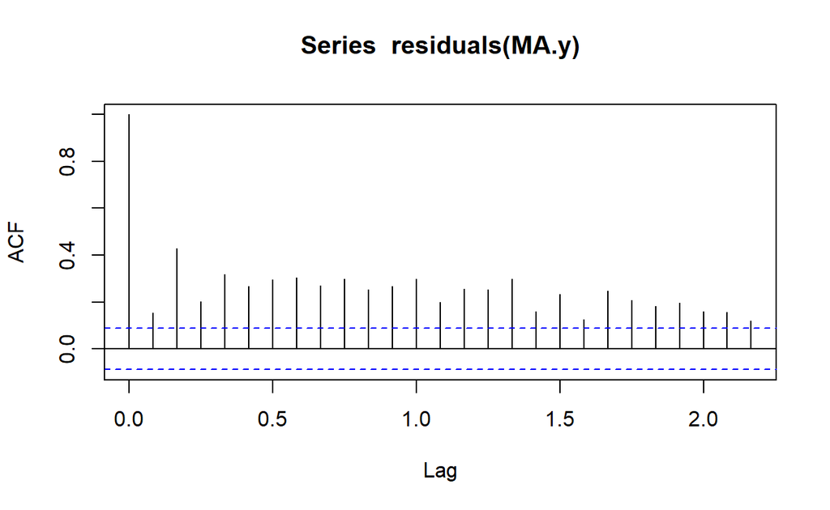

```r
# 잔차에 대한 상관도표그림
acf(residuals(MA.y))
```

`Result!` 모든 시차에서 막대의 끝이 파란색 선을 넘어가므로 모든 시차에서 자기상관계수는 통계적으로 유의하다.

`Caution!` Package `"forecast"`에서 제공하는 함수 `auto.arima()`에 옵션 `max.p = 0, max.q = 20, d = 0`을 입력하여 최적의 MA($q$) 모형을 찾을 수 있다.

```r
# 함수 auto.arima() 이용
pacman::p_load("forecast")

auto.ma.y <- auto.arima(y, max.q = 20,        # MA(1) ~ MA(20) 모형을 후보로 둠
                        max.p = 0, d = 0,
                        max.P = 0,
                        max.Q = 0,
                        max.D = 0,
                        ic = "bic")           # BIC 기준으로 BIC가 가장 작은 모형을 최적 모형으로 선택

print(auto.ma.y)
```

```
Series: y
ARIMA(0,0,4) with non-zero mean

Coefficients:
         ma1     ma2     ma3     ma4    mean
      0.4717  0.3742  0.1882  0.1544  3.9772
s.e.  0.0459  0.0489  0.0433  0.0424  0.3066

sigma^2 = 9.777:  log likelihood = -1254.13
AIC=2520.26   AICc=2520.44   BIC=2545.44
```

`Result!` 관측된 시계열에 대해 BIC를 기준으로 최적의 모형은 MA(4) 모형이다. 모수 추정 결과에 따르면, $\hat{\mu} = 3.9772$, $\hat{\theta}_1=0.4717$, $\hat{\theta}_2=0.3742$, $\hat{\theta}_3=0.1882$, $\hat{\theta}_4=0.1544$, $\hat{\sigma}^2_\epsilon = 9.777$이다. 이를 이용하면 관측된 시계열에 대해 구축된 MA(4) 모형은 $Y_t-3.9772 = \epsilon_t + 0.4717\epsilon_{t-1}+0.3742\epsilon_{t-2}+ 0.1882\epsilon_{t-3} + 0.1544\epsilon_{t-4}$이다.

```r
# 잔차를 이용한 모형 진단
Box.test(residuals(auto.ma.y), lag = 10,
         type = "Ljung-Box",
         fitdf = 4)                 # MA 모형의 추정한 회귀 모수 theta 개수
```

```
    Box-Ljung test

data:  residuals(auto.ma.y)
X-squared = 79.275, df = 6, p-value = 4.996e-15
```

`Result!` 귀무가설 $H_0 : \rho(1)=\rho(2)=\cdots=\rho(10)=0$에 대한 검정 결과에 따르면, $p$값이 0에 가까우므로 유의수준 0.05에서 $p$값이 0.05보다 작아 귀무가설을 기각한다. 즉, 잔차에 대해 시차 10까지의 자기상관계수 $\rho(1), \rho(2), \cdots, \rho(10)$ 중 유의한 자기상관계수가 적어도 1개 존재한다는 것을 의미하며, 해당 시계열에 대해 MA(4) 모형을 가정하는 것은 적절하지 않다.

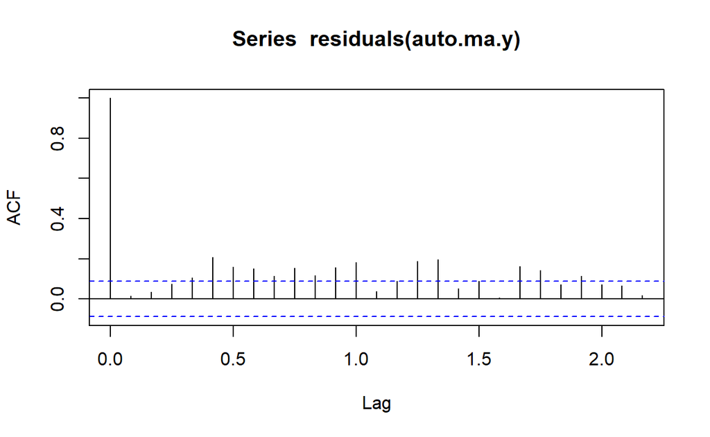

```r
# 잔차에 대한 상관도표그림
acf(residuals(auto.ma.y))
```

`Result!` 시차 4부터 막대의 끝이 파란색 선을 넘어가므로 해당 시차들에서 자기상관계수는 통계적으로 유의하다.

```r
# 함수 auto.arima() 이용
pacman::p_load("forecast")

auto.ma.y2 <- auto.arima(y, max.q = 20,        # MA(1) ~ MA(20) 모형을 후보로 둠
                         max.p = 0, d = 0,
                         max.P = 0,
                         max.Q = 0,
                         max.D = 0,
                         ic = "aic")           # AIC 기준으로 AIC가 가장 작은 모형을 최적 모형으로 선택

print(auto.ma.y2)
```

```
Series: y
ARIMA(0,0,9) with non-zero mean

Coefficients:
         ma1     ma2     ma3     ma4     ma5     ma6     ma7     ma8
      0.4223  0.3228  0.1538  0.1779  0.1662  0.1815  0.1813  0.1314
s.e.  0.0456  0.0504  0.0536  0.0541  0.0505  0.0436  0.0502  0.0448
         ma9    mean
      0.1123  3.9686
s.e.  0.0420  0.3843

sigma^2 = 9.214:  log likelihood = -1237.11
AIC=2496.22   AICc=2496.78   BIC=2542.39
```

`Result!` 관측된 시계열에 대해 AIC를 기준으로 최적의 모형은 MA(9) 모형이다. 모수 추정 결과에 따르면, $\hat{\mu} = 3.9686$, $\hat{\theta}_1=0.4223$, $\hat{\theta}_2=0.3228$, $\hat{\theta}_3=0.1538$, $\hat{\theta}_4=0.1779$, $\hat{\theta}_5=0.1662$, $\hat{\theta}_6=0.1815$, $\hat{\theta}_7=0.1813$, $\hat{\theta}_8 = 0.1314$, $\hat{\theta}_9=0.1123$, $\hat{\sigma}^2_\epsilon = 9.214$이다. 이를 이용하면 관측된 시계열에 대해 구축된 MA(9) 모형은
$$\begin{align*}
Y_t-3.9686 = & \; \epsilon_t + 0.4223\epsilon_{t-1}+0.3228\epsilon_{t-2}+0.1538\epsilon_{t-3}\\
&+ 0.1779\epsilon_{t-4}+0.1662\epsilon_{t-5}+0.1815\epsilon_{t-6} \\
&+0.1813\epsilon_{t-7}+ 0.1314\epsilon_{t-8} + 0.1123\epsilon_{t-9}
\end{align*}$$
이다.

```r
# 잔차를 이용한 모형 진단
Box.test(residuals(auto.ma.y2), lag = 10,
         type = "Ljung-Box",
         fitdf = 9)                 # MA 모형의 추정한 회귀 모수 theta 개수
```

```
    Box-Ljung test

data:  residuals(auto.ma.y2)
X-squared = 20.252, df = 1, p-value = 6.787e-06
```

`Result!` 귀무가설 $H_0 : \rho(1)=\rho(2)=\cdots=\rho(10)=0$에 대한 검정 결과에 따르면, $p$값이 0에 가까우이므로 유의수준 0.05에서 $p$값이 0.05보다 작기 때문에 귀무가설을 기각한다. 즉, 잔차에 대해 시차 10까지의 자기상관계수 $\rho(1), \rho(2), \cdots, \rho(10)$ 중 유의한 자기상관계수가 적어도 1개 존재한다는 것을 의미하며, 해당 시계열에 대해 MA(9) 모형을 가정하는 것은 적절하지 않다.

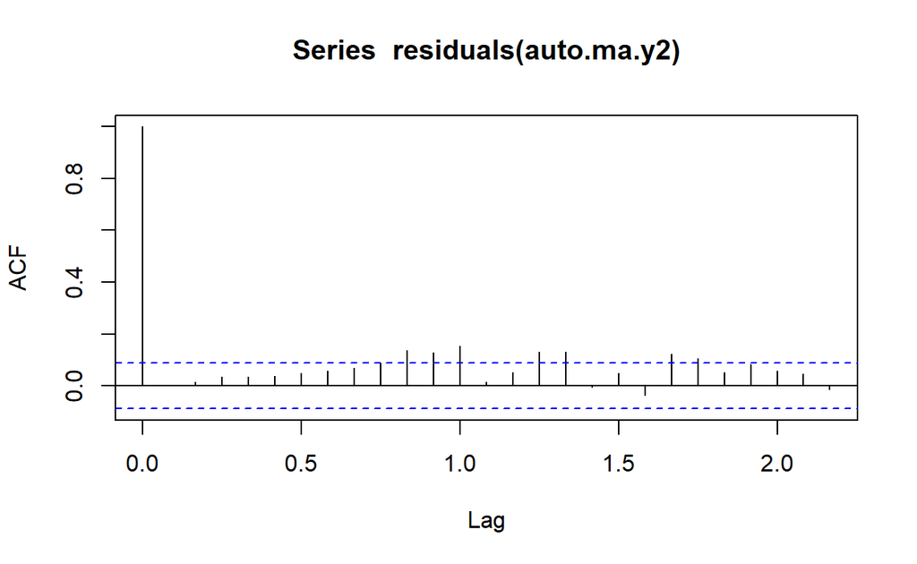

```r
# 잔차에 대한 상관도표그림
acf(residuals(auto.ma.y2))
```

`Result!` 시차 10-12까지 막대의 끝이 파란색 선을 넘어가므로 해당 시차들에서 자기상관계수는 통계적으로 유의하다.